# peerass1.Rmd

YI HAN

Sunday, April 12, 2015

# Loading and preprocessing the data

```r
#setwd("C:/Users/vannem.han/OneDrive/2_Coursera/JHU_Repro_Res/PeerAssess/1")
OriginalData <- read.csv(file="activity.csv", head=TRUE, sep=",")
```

# What is mean total number of steps taken per day?

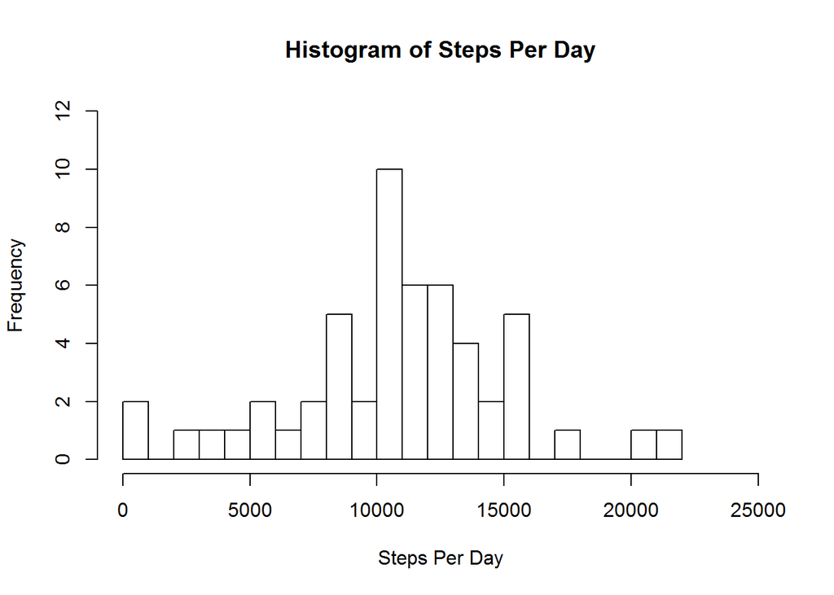

```r
Mydata <- OriginalData
Date <- Mydata[,2]
DateTable <- table(Date)

NumIntervalPerDay <- DateTable[1] #each day has 288 intervals
NumDate <- length(DateTable) #It has 61 days

StepsPerDay <- rep(0, NumDate)

for(i in 1:NumDate)
  StepsPerDay[i] = sum(Mydata[(1+NumIntervalPerDay*(i-1)):(NumIntervalPerDay+NumIntervalPerDay*(i-1)),1])

StepsPerDay = StepsPerDay[!is.na(StepsPerDay)]

hist(StepsPerDay, breaks=30, xlab="Steps Per Day", main="Histogram of Steps Per Day", xlim=c(0,25000), ylim=c(0,12))
```

```r
mean(StepsPerDay)
```

```
## [1] 10766.19
```

```r
median(StepsPerDay)
```

```
## [1] 10765
```

2. The above pic is the histogram of the total number of steps taken each day.
3. The mean and median of the otal number of steps taken per day is 10766.19 and 10765.

# What is the average daily activity pattern?

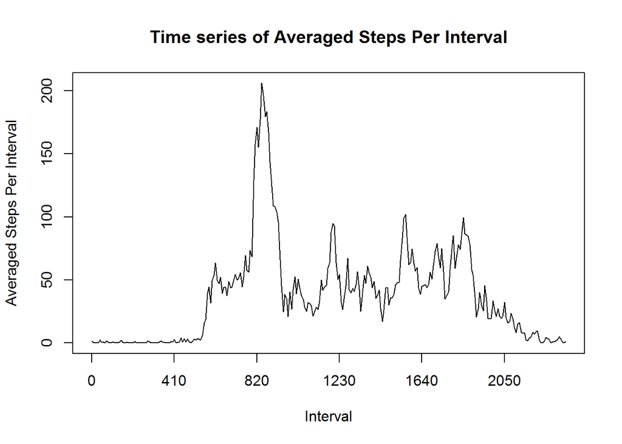

```r
StepsPerInterval <- rep(0, NumIntervalPerDay)

for(i in 1:NumIntervalPerDay)
  StepsPerInterval[i] = mean(Mydata[seq(from=i, to=i+NumIntervalPerDay*(NumDate-1), by=NumIntervalPerDay),1], na.rm=TRUE)

Interval <- Mydata[,3]
IntervalTable <- table(Interval)
IntervalNames <- names(IntervalTable) #interval names like 0 5 10 ... for plot

StepsPerInterval <- ts(StepsPerInterval)
plot(StepsPerInterval,xaxt='n', main="Time series of Averaged Steps Per Interval", ylab="Averaged Steps Per Interval", xlab="Interval")
axis(1, at=seq(1,NumIntervalPerDay,50),labels=IntervalNames[seq(1,NumIntervalPerDay,50)])
```

```r
#max(StepsPerInterval)
#which.max(StepsPerInterval)   #This-th 5 minute interval
IntervalNames[which.max(StepsPerInterval)] #This 5 minute interval
```

```
## [1] "835"
```

# Imputing missing values

```r
Mydata <- OriginalData
sum(is.na(Mydata[,1])) #the total number of missing values
```

```
## [1] 2304
```

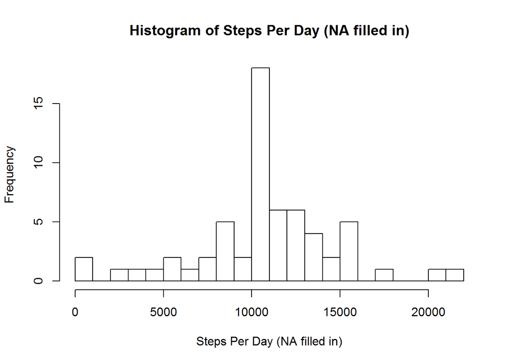

```r
NAposition = which(is.na(Mydata[,1]))

for(i in NAposition)
  Mydata[i,1] = StepsPerInterval[which(IntervalNames==Mydata[i,3])]  #My strategy: the mean for that 5-minute interval

StepsPerDay_fillin <- rep(0, NumDate)

for(i in 1:NumDate)
  StepsPerDay_fillin[i] = sum(Mydata[(1+NumIntervalPerDay*(i-1)):(NumIntervalPerDay+NumIntervalPerDay*(i-1)),1])

hist(StepsPerDay_fillin, breaks=30, xlab="Steps Per Day (NA filled in)", main="Histogram of Steps Per Day (NA filled in)")
```

```r
mean(StepsPerDay_fillin)
```

```
## [1] 10766.19
```

```r
median(StepsPerDay_fillin)
```

```
## [1] 10766.19
```

1. 2304 is the total number of missing values in the dataset.
2. I use the mean for that 5-minute interval for filling in all of the missing values in the dataset.
3. The mean and median of the NA-filled dataset is 10766.19 and 10766.19. The mean value is the same from the previou one, while the median value changes. This is because I use the mean for that 5-minute interval to fill in the NA.

# Are there differences in activity patterns between weekdays and weekends?

```r
Sys.setlocale("LC_TIME", "English") #set weekdays to be in English language
```

```
## [1] "English_United States.1252"
```

[figure not shown]

```r
DateNames <- names(DateTable)

DayorEnd <- weekdays(as.Date(DateNames))
Seq_end <- c(which(DayorEnd=="Saturday"),which(DayorEnd=="Sunday"))

DayorEnd[Seq_end] = "weekend"
DayorEnd[which(DayorEnd!="weekend")] = "weekday"
DayorEnd = factor(DayorEnd)

Weekend <- rep(0, NumIntervalPerDay)
Weekday <- rep(0, NumIntervalPerDay)

for(i in 1:NumIntervalPerDay)
{ DateOneInterval <- seq(from=i, to=i+NumIntervalPerDay*(NumDate-1), by=NumIntervalPerDay)#coresponse to DateNames and DayorEnd.

  Weekend[i] = mean(Mydata[DateOneInterval[Seq_end],1])
  Weekday[i] = mean(Mydata[DateOneInterval[-Seq_end],1])
}

df <- data.frame(IntervalNames, Weekend, Weekday)
library(reshape2)
mm <- melt(df,id.var="IntervalNames")
library(ggplot2)
ggplot(mm, aes(IntervalNames, value, group=1)) +
  #geom_point() +
  geom_line() +
  facet_grid(variable~.) +
  labs(x="Interval",y="Number of steps",title="Steps Per Interval")
```